# Tarea: intervalos de confianza

Abraham Nieto

9/13/2017

### 1. ENIGH

Para este ejercicio usaremos los datos de la [ENIGH](http://www.inegi.org.mx/est/contenidos/proyectos/encuestas/hogares/regulares/enigh/) (2014). En la tabla concentradohogar que vimos en clase se incluyen las variables alimentos, vestido, vivienda, salud, comunica, educacion y esparci (esparcimiento) que indican el gasto trimestral en cada una de las categorías.

```r
concentrado_hogar <- read_csv("concentradohogar.csv")
hogar <- concentrado_hogar %>%
    select(folioviv, foliohog, est_dis, upm, factor_hog, ing_cor, alimentos,
        vestido, vivienda, salud, transporte, comunica, educacion, esparci)
```

Nos interesa analizar los patrones de gasto por decil de ingreso, para ello sigue los siguientes pasos.

1. Calcula los deciles de ingreso usando la variable de ingreso corriente (ing_cor). Debes tomar en cuenta el diseño de la muestra, puedes usar la función `survey_quantile()` del paquete `srvyr` o `svyquantile()` del paquete `survey`. Reporta las estimaciones y sus errores estándar usando el bootstrap de Rao y Wu.

```r
library(srvyr)
library(survey)
enigh_design <- hogar %>%
    as_survey_design(ids = upm, weights = factor_hog, strata = est_dis)

set.seed(7398731)
enigh_boot <- enigh_design %>%
    as_survey_rep(type = "subbootstrap", replicates = 500)

enigh_boot %>%
    srvyr::summarise(mean_ingcor = survey_mean(ing_cor))
```

```
## # A tibble: 1 x 2
##   mean_ingcor mean_ingcor_se
##         <dbl>          <dbl>
## 1    39719.11       1007.578
```

```r
qq<-svyquantile(~ing_cor, enigh_boot, quantiles = seq(0.1, 1, 0.1), interval.type = "quantile")
qq
```

```
## Statistic:
##         ing_cor
## q0.1   10622.27
## q0.2   14775.08
## q0.3   18597.46
## q0.4   22682.01
## q0.5   27185.82
## q0.6   32725.96
## q0.7   40057.31
## q0.8   51990.48
## q0.9   76284.93
## q1   4150377.02
## SE:
##           ing_cor
## q0.1     143.8969
## q0.2     165.3970
## q0.3     192.9999
## q0.4     218.3764
## q0.5     239.4185
## q0.6     347.5548
## q0.7     483.5168
## q0.8     768.6227
## q0.9    1322.1179
## q1   1318629.0964
```

2. Crea una nueva variable que indique el decil de ingreso para cada hogar. Tips: 1) una función que puede resultar útil es `cut2()` (de `Hmisc`),
2. si usas el paquete `srvyr` puedes usar `mutate()` sobre el objeto `survey` con pesos de replicaciones bootstrap.

```r
library(Hmisc)
```

```r
hogar$decil<-as.character(cut2(hogar$ing_cor,qq))
hogar
```

```
## # A tibble: 19,479 x 15
##      folioviv foliohog est_dis   upm factor_hog   ing_cor alimentos
##         <chr>    <int>   <chr> <chr>      <int>     <dbl>     <dbl>
##  1 0100008302        1     005 00670        694  39786.79  11172.63
##  2 0100008303        1     005 00670        694  19523.90   1941.38
##  3 0100008304        1     005 00670        694  99257.66  16759.08
##  4 0100008305        1     005 00670        694  87883.68   8678.43
##  5 0100010401        1     005 00600        660  84427.04  12873.09
##  6 0100010402        1     005 00600        660 232013.81  18530.30
##  7 0100010403        1     005 00600        660  90941.45  10819.12
##  8 0100010404        1     005 00600        660  70308.55  12490.53
##  9 0100010405        1     005 00600        660  92507.81   6852.70
## 10 0100018702        1     004 00570        583  80865.03  12876.13
## # ... with 19,469 more rows, and 8 more variables: vestido <dbl>,
## #   vivienda <dbl>, salud <dbl>, transporte <dbl>, comunica <dbl>,
## #   educacion <dbl>, esparci <dbl>, decil <chr>
```

3. Estima para cada decil, el porcentaje del gasto en cada categoría, reporta el error estándar de las estimaciones, usa el bootstrap de Rao y Wu. Tip: 1) agrega una variable que indica para cada hogar el porcentaje de gasto en cada categoría, 2) si usas srvyr puedes usar la función `group_by()` para estimar la media del porcentaje de gasto por decil.

```r
zer<-function(x){
  if(x==0){
    return(.01)
  }
  else{
    return(x)
  }
}

den<-sapply((hogar$alimentos+hogar$vestido+hogar$vivienda+hogar$salud+hogar$transporte+hogar$comunica+hogar$educacion+hogar$esparci),zer)

hogar$palim<-(hogar$alimentos/den)
hogar$pvestido<-hogar$vestido/den
hogar$pvivienda<-hogar$vivienda/den
hogar$psalud<-hogar$salud/den
hogar$ptransporte<-hogar$transporte/den
hogar$pcomunica<-hogar$comunica/den
hogar$peducacion<-hogar$educacion/den
hogar$pesparci<-hogar$esparci/den



enigh_design2 <- hogar %>%
    as_survey_design(ids = upm, weights = factor_hog, strata = est_dis)

enigh_boot2 <- enigh_design2 %>%
    as_survey_rep(type = "subbootstrap", replicates = 500)


fin<-data.frame(enigh_boot2 %>%
    srvyr::group_by(decil) %>%
    srvyr::summarise(mean_palim = survey_mean(palim),mean_pvestido = survey_mean(pvestido),mean_pvivienda = survey_mean(pvivienda),mean_psalud = survey_mean(psalud),mean_ptransporte = survey_mean(ptransporte),mean_pcomunica = survey_mean(pcomunica),mean_peducacion = survey_mean(peducacion),mean_pesparci = survey_mean(pesparci)))
fin
```

```
##                decil mean_palim mean_palim_se mean_pvestido
## 1  [      0,  10622)  0.6294435   0.006141348    0.02736907
## 2  [  10622,  14775)  0.5714863   0.005504064    0.02838772
## 3  [  14775,  18597)  0.5397263   0.004881901    0.02656811
## 4  [  18597,  22682)  0.5241734   0.004554655    0.02746975
## 5  [  22682,  27186)  0.4963811   0.005002542    0.02771933
## 6  [  27186,  32726)  0.4774084   0.004747735    0.03010250
## 7  [  32726,  40057)  0.4531834   0.004733096    0.03174477
## 8  [  40057,  51990)  0.4307530   0.004281828    0.03465659
## 9  [  51990,  76285)  0.3976248   0.004432105    0.03584568
## 10 [  76285,4150377]  0.3235232   0.005276222    0.04236249
##    mean_pvestido_se mean_pvivienda mean_pvivienda_se mean_psalud
## 1       0.001469993      0.1303336       0.004484477  0.02595083
## 2       0.001518310      0.1361030       0.003598572  0.02888787
## 3       0.001241573      0.1350544       0.003022089  0.02196807
```

[output cut: 40 more lines]

4. Realiza una gráfica con las estimaciones del paso 3.

```r
library(ggplot2)
library(plotly)
ggplotly(ggplot()+geom_point(data=fin,aes(x=decil,y=mean_pvestido,color='vestido'))+geom_point(data=fin,aes(x=decil,y=mean_psalud,color='salud'))+geom_point(data=fin,aes(x=decil,y=mean_palim,color='alimentos'))+geom_point(data=fin,aes(x=decil,y=mean_pvivienda,color='vivienda'))+geom_point(data=fin,aes(x=decil,y=mean_ptransporte,color='transporte'))+geom_point(data=fin,aes(x=decil,y=mean_pcomunica,color='comunica'))+geom_point(data=fin,aes(x=decil,y=mean_peducacion,color='educacion'))+geom_line(data=fin,aes(x=decil,y=mean_pesparci,color='esparcimiento')))
```

```
## We recommend that you use the dev version of ggplot2 with `ggplotly()`
## Install it with: `devtools::install_github('hadley/ggplot2')`
```

[interactive chart not shown]

las estimaciones muestran como la proporción de gasto en alimentos es menor mientras más ganas, así como el gasto en transporte es mayor mientras más ganas al igual que el gasto en vestido.

### 2. Cobertura de intervalos

Vamos a retomar de simulación que vimos en clase, donde comparamos los intervalos de confianza construidos con el método de percentiles y usando la aproximación normal ($\hat{\theta} \pm 1.96 \hat{se}$).

Generamos una muestra de tamaño 30 (en clase era 10) de una distribución normal estándar, el parámetro de interés es $e^{\mu}$ donde $\mu$ es la media poblacional.

```r
set.seed(766587)
x <- rnorm(30)
```

1. Construye intervalos de confianza con el método de percentiles y de aproximación normal.

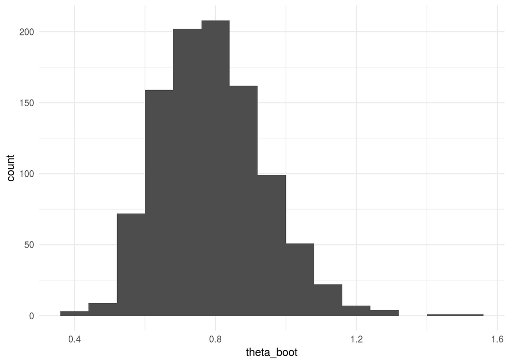

```r
boot_sim_exp <- function(){
  x_boot <- sample(x, size = 30, replace = TRUE)
  exp(mean(x_boot))
}
theta_boot <- rerun(1000, boot_sim_exp()) %>% flatten_dbl()
theta_boot_df <- data_frame(theta_boot)

hist_emu <- ggplot(theta_boot_df, aes(x = theta_boot)) +
    geom_histogram(fill = "gray30", binwidth = 0.08)
qq_emu <- ggplot(theta_boot_df) +
    geom_abline(color = "red", alpha = 0.5) +
    stat_qq(aes(sample = theta_boot),
        dparams = list(mean = mean(theta_boot), sd = sd(theta_boot)))

#grid.arrange(hist_emu, qq_emu, ncol = 2, newpage = FALSE)
hist_emu
```

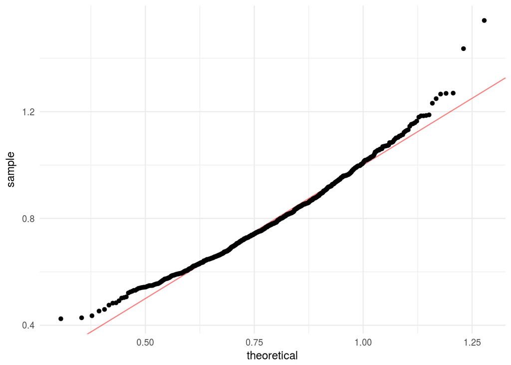

```r
qq_emu
```

Hacemos una transformación logaritmica pra normalizar los datos:

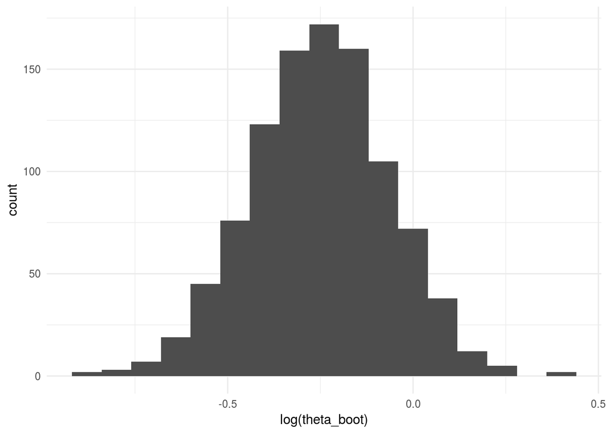

```r
hist_log <- ggplot(data_frame(theta_boot), aes(x = log(theta_boot))) +
  geom_histogram(fill = "gray30", binwidth = 0.08)
qq_log <- ggplot(data_frame(theta_boot)) +
    geom_abline(color = "red", alpha = 0.5) +
    stat_qq(aes(sample = log(theta_boot)),
        dparams = list(mean = mean(log(theta_boot)), sd = sd(log(theta_boot))))
hist_log
```

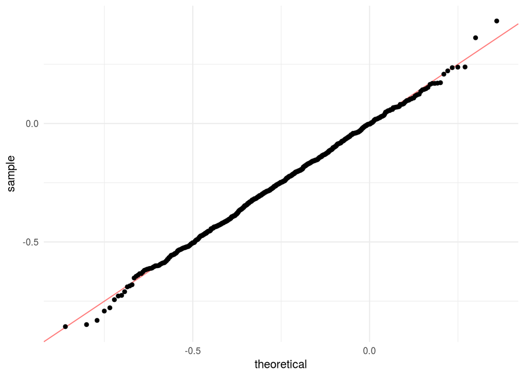

```r
qq_log
```

y mapeando la transformación de regreso tenemos los intervalos de confianza siguientes para $e^{\mu}$:

```r
#Con el intervalo Normal tenemos:
n1<-exp(round(mean(x) - 1.96 * sd(log(theta_boot)), 2))

n2<-exp(round(mean(x) + 1.96 * sd(log(theta_boot)), 2))

#Con quantiles:
q1<-exp(round(quantile(log(theta_boot), prob = 0.025), 2))

q2<-exp(round(quantile(log(theta_boot), prob = 0.975), 2))
n1
```

```
## [1] 0.5379444
```

```r
n2
```

```
## [1] 1.105171
```

```r
q1
```

```
##      2.5%
## 0.5433509
```

```r
q2
```

```
##    97.5%
## 1.105171
```

2. ¿Cuál tiene mejor cobertura? Realiza 500 simulaciones de vectores de tamaño 30 de una normal estándar, para cada simulación calcula $\hat{\theta}$ y calcula el porcentaje de realizaciones que caen dentro de cada intervalo de confianza.

```r
set.seed(0)
cae<-function(x,inf,sup){

  if(x>=inf & x<=sup){
    a<-1
  }
  else{
    a<-0
  }
  return(a)
}
sals<-c(rep(0,500))
for(i in 1:500){
sals[i]<-exp(mean(rnorm(30)))
}
```

Para el intervalo de la normal tenemos que:

```r
 perc<-c(rep(0,500))
for(i in 1:500){
  perc[i]<-cae(sals[i],n1,n2)
}
normal<-mean(perc)
normal
```

```
## [1] 0.7
```

vemos que el 70% de los parámetros están dentro del intervalo

y con los cuantíles tenemos que:

```r
 percx<-c(rep(0,500))
for(i in 1:500){
  percx[i]<-cae(sals[i],q1,q2)
}
quant<-mean(percx)
quant
```

```
## [1] 0.7
```

el 70% de los casos caen en el inervalo por tanto ajustan igual.